# Semesterbegleitende Abgabe WiSe2026-27

# Statistik im Bachelor Wirtschaftsinformatik

Dozent_innen: Martin Spott, Michael Heimann, Anja Hirsch  
Stand: 25.10.2026

**Gruppe:**

Gruppe D

**Autor_innen:**

Jakob Fahr  
Anahita Karimi  
David Marcel Mayer  
Timo Wahl

## Einleitung

In diesem Semester beschäftigen wir uns mit Kraftstoffpreisen in Berlin. Dazu benutzen wir Daten von der Organisation Tankerkönig [1], die jede Preisänderung angeschlossener Tankstellenbetreiber_innen mit Zeitstempel protokolliert. In der Datei *tankerkoenig_WiSe2026-27_1.csv* finden Sie den Ausschnitt der Daten, den Sie für die Aufgaben benutzen sollen. Dabei haben wir für jede Tankstelle und jede Stunde den Median der von Tankerkönig registrierten Preisänderungen der Kraftstoffe Diesel und E10 ermittelt.

### Regeln

Arbeiten Sie in Ihrer Moodlegruppe von bis zu vier Studierenden, die alle in derselben Übungsgruppe sein und die eine zu wählende Abgabe auch in den zugehörigen Übungen vorstellen müssen (Terminkalender folgt). Jede/r von Ihnen hat in Moodle nur Zugriff auf die Gruppeneinteilung Ihrer in LSF festgelegten Übungsgruppe, wo Sie sich in einer Gruppe eintragen müssen, um Punkte zu bekommen.

Bearbeiten Sie die Aufgaben fortlaufend in diesem RMarkdown-Dokument und **geben es bei jeder Teilabgabe komplett als RMarkdown- und als mit Knit übersetztes HTML-Dokument ab**. Stellen Sie sicher, dass das RMarkdown-Dokument auch für uns lauffähig ist. Gehen Sie dazu davon aus, dass sich auf unseren Rechnern die Daten im selben Verzeichnis befinden werden wie Ihr RMarkdown-Dokument.

Benutzen Sie nur Verfahren und Techniken, die wir in der Vorlesung besprochen haben. Sie können aber gerne komplexere Visualisierungen einsetzen, wenn dies sinnvoll erscheint.

Erklären Sie kurz Ihr Vorgehen vor jedem Codeabschnitt und interpretieren die Ergebnisse danach. Schreiben Sie Erklärungen/Interpretationen in Textform zwischen die Codeblöcke, nicht als Kommentare in die Codeblöcke. Sie können den Code aber gerne zusätzlich knapp kommentieren.

Für jede weitere Woche bekommen Sie eine Aufgabenstellung in RMarkdown, die Sie bitte in diesem Dokument fortlaufend anhängen und dort bearbeiten. Geben Sie immer das gesamte Dokument einschließlich der vorangehenden Aufgaben ab, da die Aufgaben teilweise aufeinander aufbauen und Sie vorangehende Lösungen später benötigen.

## Woche 1 – 27.10.2026

Beschreiben Sie zwischen den Codeblöcken in Textform, was Sie warum tun und was Sie herausfinden.

1. Importieren Sie die Daten.
2. Beschreiben Sie die Daten. Was sind die Merkmale, was die Merkmalsträger?
3. Geben Sie für alle Merkmale an, ob sie qualitativ/quantitativ, diskrekt/stetig und auf welchen Skalen sie definiert sind.
4. Berechnen Sie für das Merkmal `brand` (Marke) die Tabellen mit absoluter und relativer Häufigkeit.
5. Stellen Sie die Tabelle absoluter Häufigkeit von `brand` als Balkendiagramm dar. Beschriften Sie alle Axen und geben dem Diagramm eine Überschrift.
6. Was bedeuten die absoluten Häufigkeiten im Kontext unserer Daten? Warum gibt es Unterschiede zwischen den Werten der verschiedenen Marken?

### a. Datenimport

Die Daten liegen im CSV Format. Wir lesen sie mit `read.csv()` ein und speichern sie unter dem Namen `tanken`, damit wir sie in den folgenden Aufgaben auswerten können.

```r
   tanken <- read.csv("tankerkoenig_WiSe2026-27_1.csv")
```

Der Datensatz enthält 478274 Zeilen und 13 Spalten.

### b. Beschreibung der Daten

Um uns einen Überblick zu verschaffen, lassen wir uns die ersten Zeilen und die Struktur der Daten anzeigen.

```r
head(tanken)
```

```
##   X                                   id       date  time            name brand
## 1 0 005056ba-7cb6-1ed2-bceb-6d1d63fd4d20 2025-02-01 07:30 star Tankstelle  STAR
## 2 1 005056ba-7cb6-1ed2-bceb-6d1d63fd4d20 2025-02-01 08:30 star Tankstelle  STAR
## 3 2 005056ba-7cb6-1ed2-bceb-6d1d63fd4d20 2025-02-01 09:30 star Tankstelle  STAR
## 4 3 005056ba-7cb6-1ed2-bceb-6d1d63fd4d20 2025-02-01 10:30 star Tankstelle  STAR
## 5 4 005056ba-7cb6-1ed2-bceb-6d1d63fd4d20 2025-02-01 11:30 star Tankstelle  STAR
## 6 5 005056ba-7cb6-1ed2-bceb-6d1d63fd4d20 2025-02-01 12:30 star Tankstelle  STAR
##                  street house_number post_code opening_time closing_time
## 1 Finckensteinallee 133         <NA>     12205        07:00        22:00
## 2 Finckensteinallee 133         <NA>     12205        07:00        22:00
## 3 Finckensteinallee 133         <NA>     12205        07:00        22:00
## 4 Finckensteinallee 133         <NA>     12205        07:00        22:00
## 5 Finckensteinallee 133         <NA>     12205        07:00        22:00
## 6 Finckensteinallee 133         <NA>     12205        07:00        22:00
##   e10_median diesel_median
## 1         NA            NA
## 2       1779          1704
## 3       1709          1639
## 4       1684          1609
## 5       1649          1589
## 6       1679          1609
```

```r
str(tanken)
```

```
## 'data.frame':    478274 obs. of  13 variables:
##  $ X            : int  0 1 2 3 4 5 6 7 8 9 ...
##  $ id           : chr  "005056ba-7cb6-1ed2-bceb-6d1d63fd4d20" "005056ba-7cb6-1ed2-bceb-6d1d63fd4d20" "005056ba-7cb6-1ed2-bceb-6d1d63fd4d20" "005056ba-7cb6-1ed2-bceb-6d1d63fd4d20" ...
##  $ date         : chr  "2025-02-01" "2025-02-01" "2025-02-01" "2025-02-01" ...
##  $ time         : chr  "07:30" "08:30" "09:30" "10:30" ...
##  $ name         : chr  "star Tankstelle" "star Tankstelle" "star Tankstelle" "star Tankstelle" ...
##  $ brand        : chr  "STAR" "STAR" "STAR" "STAR" ...
##  $ street       : chr  "Finckensteinallee 133" "Finckensteinallee 133" "Finckensteinallee 133" "Finckensteinallee 133" ...
##  $ house_number : chr  NA NA NA NA ...
##  $ post_code    : int  12205 12205 12205 12205 12205 12205 12205 12205 12205 12205 ...
##  $ opening_time : chr  "07:00" "07:00" "07:00" "07:00" ...
##  $ closing_time : chr  "22:00" "22:00" "22:00" "22:00" ...
##  $ e10_median   : int  NA 1779 1709 1684 1649 1679 1699 1684 1709 1699 ...
##  $ diesel_median: int  NA 1704 1639 1609 1589 1609 1629 1619 1639 1619 ...
```

Der Datensatz enthält stündliche Kraftstoffpreise von Berliner Tankstellen. Der Merksmalsträger ist eine Tankstelle in einer bestimmten Stunde an einem bestimmten Tag. Grundgesamtheit sind alle Stunden der 78 Tankstellen in Berlin von Februar 2025 bis Januar 2026. Merkmale sind die Spalten: - `X`: die Zeilennummer - `id`: eindeutige ID der Tankstelle - `date`, `time`: Datum und Stunde - `name`, `brand`: Name und Marke der Tankstelle - `street`, `house_number`, `post_code`: Adresse der Tankstelle - `opening_time`, `closing_time`: Öffnungs und Schließzeit - `e10_median`, `diesel_median`: Median der Preise für E10 und Diesel in dieser Stunde. Die Preise sind in Euro pro Liter angegeben, aber ohne Komma.

Bei einigen Zeilen fehlen die Preise (`NA`).

### c. Merkmalstypen

| Merkmal | qualitativ/quantitativ | diskret/stetig | Skala |
| --- | --- | --- | --- |
| `X` | quantitativ | diskret | Ordinalskala |
| `id` | qualitativ | diskret | Nominalskala |
| `date` | quantitativ | diskret | Intervallskala |
| `time` | quantitativ | diskret | Intervallskala |
| `name` | qualitativ | diskret | Nominalskala |
| `brand` | qualitativ | diskret | Nominalskala |
| `street` | qualitativ | diskret | Nominalskala |
| `house_number` | qualitativ | diskret | Nominalskala |
| `post_code` | qualitativ | diskret | Nominalskala |
| `opening_time` | quantitativ | diskret | Intervallskala |
| `closing_time` | quantitativ | diskret | Intervallskala |
| `e10_median` | quantitativ | quasi-stetig | Verhältnisskala |
| `diesel_median` | quantitativ | quasi-stetig | Verhältnisskala |

Postleitzahl, Hausnummer und id bestehen zwar teilweise aus Ziffern, sind aber nur Bezeichnungen, mit denen man nicht rechnen kann. Deshalb sind sie qualitativ und nominal. Datum und Uhrzeiten sind intervallskaliert. Abstände sind sinnvoll, aber der Nullpunkt ist willkürlich. Die Preise sind verhältnisskaliert, weil 0 € ein echter Nullpunkt ist. Sie sind quasi-stetig, weil sie gerundet angegeben werden.

### d. Häufigkeiten der Marken

Wir zählen mit `table()`, wie oft jede Marke im Datensatz vorkommt (absolute Häufigkeit), und rechnen das mit `prop.table()` in Anteile um (relative Häufigkeit). Die Anteile runden wir mit `round()` auf drei Nachkommastellen.

```r
brand_abs <- table(tanken$brand)
brand_abs
```

```
##
##      AGIP ENI          ARAL          ESSO           HEM           JET
##         23595         52758         34385         35734         30489
##         Shell        Sprint          STAR TotalEnergies
##         95828         36423        102928         66134
```

```r
brand_rel <- prop.table(brand_abs)
round (brand_rel, 3)
```

```
##
##      AGIP ENI          ARAL          ESSO           HEM           JET
##         0.049         0.110         0.072         0.075         0.064
##         Shell        Sprint          STAR TotalEnergies
##         0.200         0.076         0.215         0.138
```

### e. Balkendiagramm

Da `brand` ein qualitatives Merkmal ist, stellen wir die absoluten Häufigkeiten als Balkendiagramm dar. Damit alle Markennamen lesbar sind, verkleinern wir sie (mit `cex.names`) und drehen sie senkrecht (mit `las = 2`). Mit options(`scipen = 999`) werden die Zahlen an der y Achse ausgeschrieben (z. B. 100000 statt 1e+05).

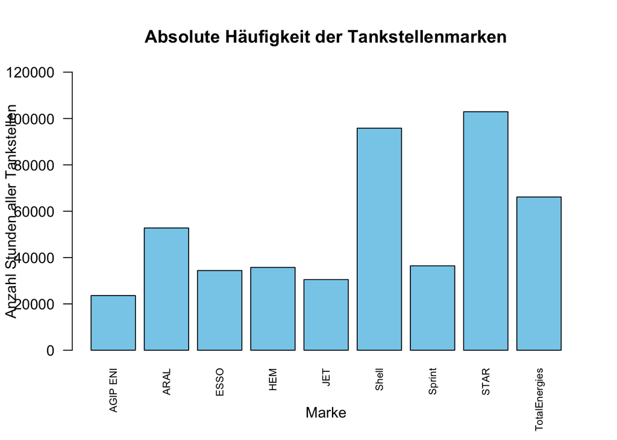

```r
options(scipen = 999)
barplot(brand_abs,
        main = "Absolute Häufigkeit der Tankstellenmarken",
        xlab = "Marke",
        ylab = "Anzahl Stunden aller Tankstellen",
        ylim = c(0, 120000),
        cex.names = 0.7,
        las = 2,
        col = "skyblue")
```

Auf der x Achse sind die Tankstellenmarken. Auf der y Achse ist die absolute Häufigkeit dargestellt, also die Anzahl der Stunden, für die im Datensatz ein Preis einer Tankstelle dieser Marke vorliegt (zusammengezählt über alle Tankstellen der Marke und das ganze Jahr). Jeder Balken steht für eine Marke, und seine Höhe zeigt, wie oft diese Marke im Datensatz vorkommt. Am häufigsten kommt STAR vor, dicht gefolgt von Shell. Mit Abstand folgt TotalEnergies, am seltensten ist AGIP ENI.

### f. Interpretation der Häufigkeiten

Die absolute Häufigkeit einer Marke gibt an, für wie viele Stunden im Datensatz ein Preis einer Tankstelle dieser Marke vorliegt, zusammengezählt über alle Berliner Tankstellen der Marke im Zeitraum von Februar 2025 bis Januar 2026.

Die Unterschiede können vor allem durch die Anzahl der Tankstellen je Marke entstehen. STAR hat im Datensatz 17 Tankstellen, Shell 15, AGIP ENI dagegen nur 4. Je mehr Tankstellen eine Marke hat, desto mehr Stunden kommen zusammen. Außerdem sind die Öffnungszeiten auch relevant, je länger eine Tankstelle geöffnet hat, desto mehr Stunden mit Preisen gibt es im Datensatz.

```r
tankstellen <- unique(tanken[, c("id", "brand")])
table(tankstellen$brand)
```

```
##
##      AGIP ENI          ARAL          ESSO           HEM           JET
##             4             9             6             5             5
##         Shell        Sprint          STAR TotalEnergies
##            15             6            17            11
```

**—Fügen Sie hier kommende Aufgabenbeschreibungen mit Lösungen ein —**

## Quellen

[1] Tankerkönig UG, URL: https://tankerkoenig.de, letzter Aufruf: 21.10.2026